# Networks

2026-06-22

# Task One

```r
library(tidyverse)
```

```r
library(ggplot2)
library(tibble)

network_colnames = c('Regulator_systematic', 'Regulator_standard', 'Target_systematic', 'Target_standard', 'Id', 'Date', 'Environment', 'Regulation', 'Type', 'Method')

yeast_network <- read_tsv("yeastract2019-flat-file.tsv", col_names = network_colnames)
tf_count <- yeast_network %>% distinct(Regulator_systematic) %>% nrow()

target_count <- yeast_network %>% distinct(Target_systematic) %>% nrow()

cat("Number of TF:", tf_count)
```

```
## Number of TF: 220
```

```r
cat("number of target genes:", target_count)
```

```
## number of target genes: 6886
```

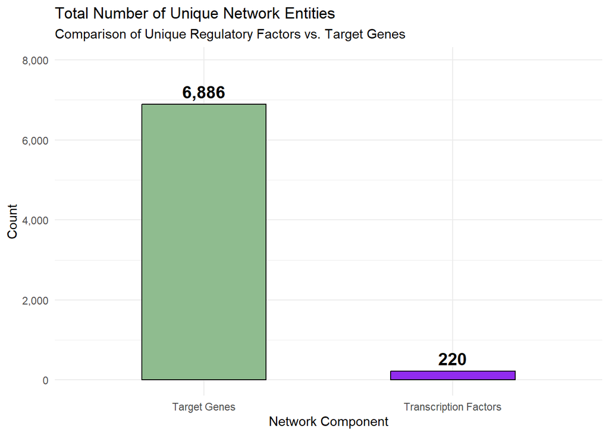

```r
nodes_data <- data.frame(
  Category = c("Transcription Factors", "Target Genes"),
  Count = c(tf_count, target_count))

  ggplot(nodes_data, aes(x = Category, y = Count, fill = Category)) +
    geom_bar(stat = "identity", color = "black", width = 0.5) +
    geom_text(aes(label = scales::comma(Count)), vjust = -0.5, color = "black", fontface = "bold", size = 5) + scale_fill_manual(values = c("Transcription Factors" = "purple2", "Target Genes" = "darkseagreen")) +
    scale_y_continuous(labels = scales::comma) +
    expand_limits(y = max(tf_count, target_count) * 1.15) +
    labs(
    title = "Total Number of Unique Network Entities",
    subtitle = "Comparison of Unique Regulatory Factors vs. Target Genes",
    x = "Network Component",
    y = "Count") +
    theme_minimal() +
    theme(legend.position = "none")
```

There are fare more Target genes compared to Transcription factors, which means that the Transcription Factors regulate lots of different genes.This can be seen later on in this analysis

```r
total_edges <- nrow(yeast_network)

unique_pairs <- yeast_network %>% distinct(Regulator_systematic, Target_systematic) %>% nrow()

redundant_edges <- total_edges - unique_pairs

cat("Total numbers of edges:", total_edges)
```

```
## Total numbers of edges: 315497
```

```r
cat("Number of unique regulator-target-pairs:", unique_pairs)
```

```
## Number of unique regulator-target-pairs: 195498
```

```r
cat("Number of redundant regulator-target pairs:", redundant_edges)
```

```
## Number of redundant regulator-target pairs: 119999
```

[figure not shown]

```r
plot_data <- data.frame(
  Type = c("Unique Pairs", "Redundant Edges"), Count = c(unique_pairs, redundant_edges))

ggplot(plot_data, aes(x = Type, y = Count, fill = Type)) + geom_bar(stat = "identity", color = "black", width = 0.6) +
  geom_text(aes(labels = scales::comma(Count)), vjust = - 0.7, color = "black", fontface = "bold", size =  5) +
  scale_fill_manual(values = c("Unique Pairs" = "skyblue", "Redundant Edges" = "salmon")) +
  scale_y_continuous(labels = scales::comma) +
  ylim(0, 220000) +
  labs(title = "Comparison of Uniqe ve. Reduntand Netword Edges", subtitle = paste("Total observed rows in File:", scales::comma(total_edges)),
       x = "Edge Category",
       y = "Number of Edges") +
  theme_minimal() +
  theme(legend.position = "none")
```

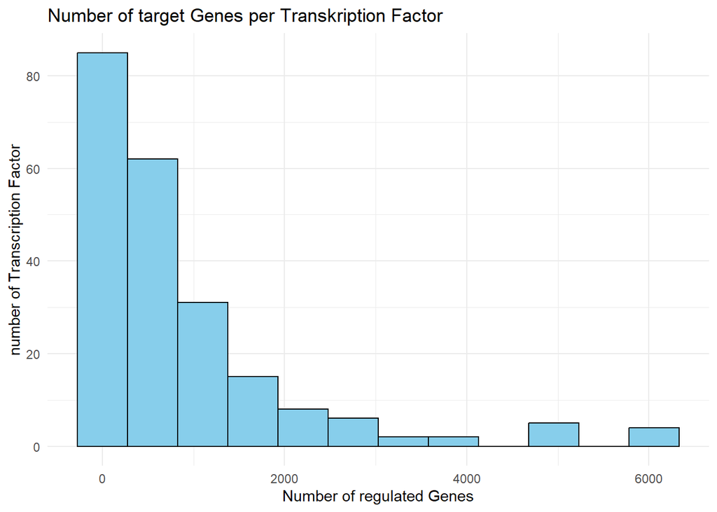

```r
targets_per_tf <- yeast_network %>% group_by(Regulator_systematic) %>% summarize(number_targets = n_distinct(Target_systematic))

ggplot(targets_per_tf, aes(x = number_targets)) + geom_histogram(bins = 12, fill = "skyblue", color = "black") + labs(title = "Number of target Genes per Transkription Factor", x = "Number of regulated Genes", y = "number of Transcription Factor") + theme_minimal() + scale_y_continuous(breaks = seq(0, 100, by = 20))
```

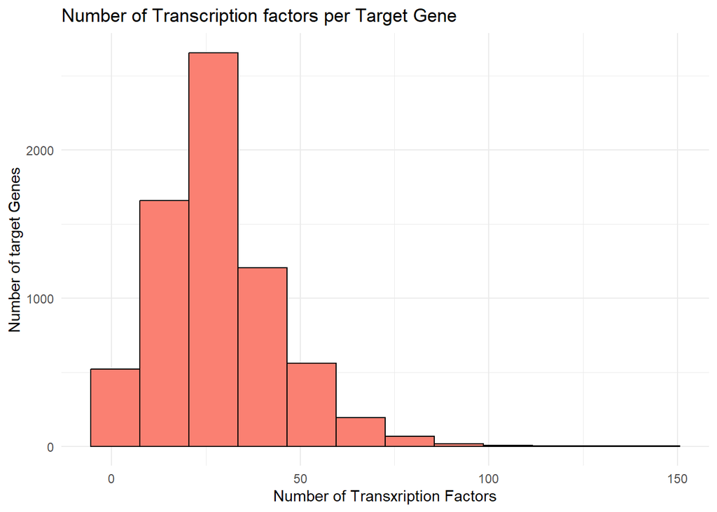

```r
tf_per_target <- yeast_network %>% group_by(Target_systematic) %>% summarize(number_tf = n_distinct(Regulator_systematic))

ggplot(tf_per_target, aes(x = number_tf)) + geom_histogram(bins = 12, fill = "salmon", color = "black") + labs(title = "Number of Transcription factors per Target Gene", x = "Number of Transxription Factors", y = "Number of target Genes") + theme_minimal()
```

The first histogram displays the number of unique target genes regulated by individual transcription factors (TFs), representing the network’s out-degree distribution.

Network Hubs: Conversely, a selective handful of highly connected TFs act as global network “hubs,” regulating an exceptionally high number of genes (some controlling over 6,000 targets). Biologically, these hubs represent master regulators responsible for fundamental cellular processes, global stress responses, or large-scale metabolic shifts.

The second histogram displays the number of distinct transcription factors regulating a single target gene, representing the network’s in-degree distribution.

Combinatorial Regulation: Unlike the out-degree distribution, this profile is shifted to the right, showing a clear peak where the majority of target genes are regulated by approximately 20 to 40 different transcription factors simultaneously.

Biological Significance: This pattern is indicative of complex combinatorial regulation in eukaryotic systems. Most yeast genes do not rely on a simple on/off switch controlled by a single factor. Instead, their expression is fine-tuned via integrating inputs from multiple upstream regulators, allowing the cell to precisely coordinate gene expression based on complex environmental and physiological cues.

```r
timeframe <- yeast_network %>% mutate(Year = as.numeric(str_sub(Date, start = 1, end = 4)))
```

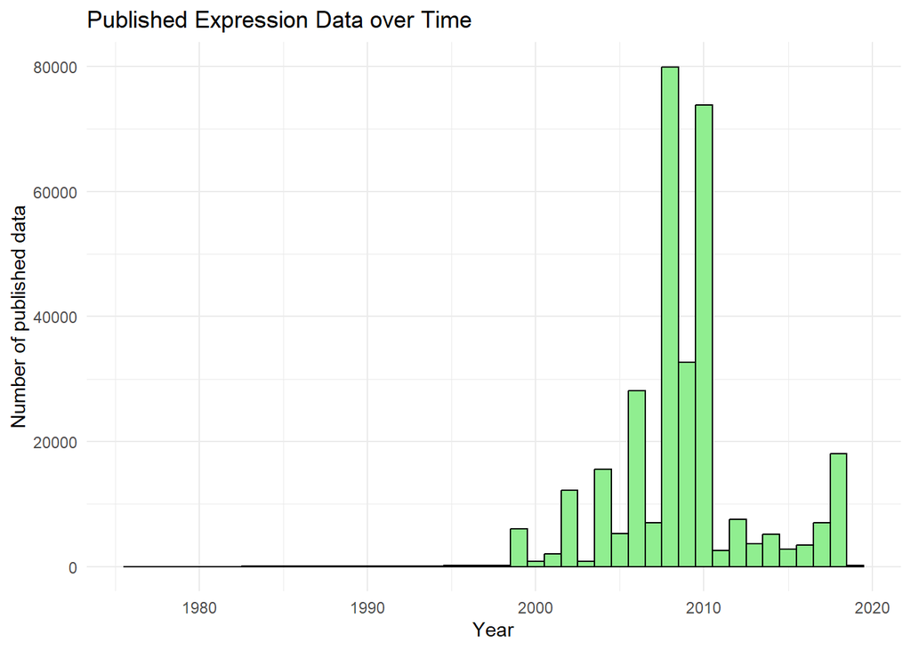

```r
ggplot(timeframe, aes(x = Year)) + geom_histogram(binwidth = 1, fill = "lightgreen", color = "black") + labs(title = "Published Expression Data over Time", x = "Year", y = "Number of published data") + theme_minimal()
```

The timeframe of the histogram is between 1976 and 2019, with a peak in published data in 2008

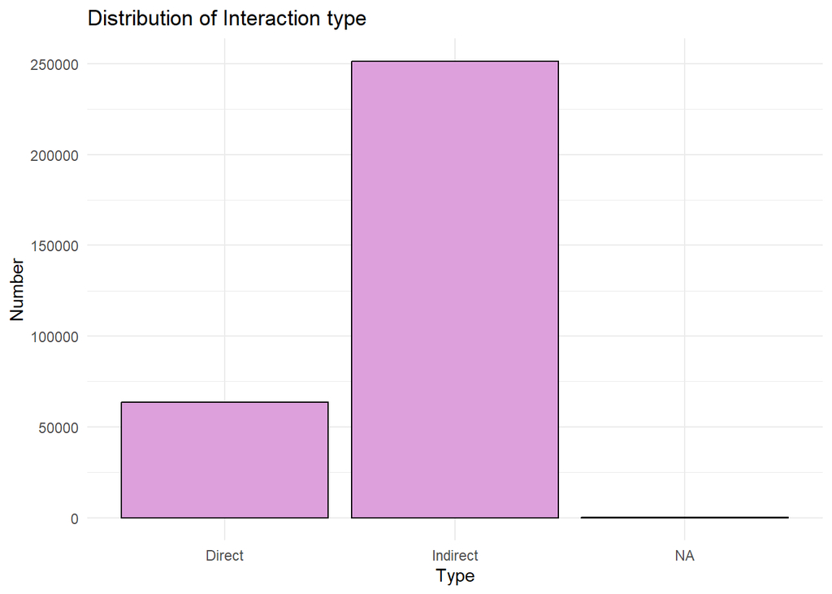

```r
ggplot(yeast_network, aes(x = Type)) + geom_bar(fill = "plum", color = "black") + labs(title = "Distribution of Interaction type", x = "Type", y = "Number") + theme_minimal()
```

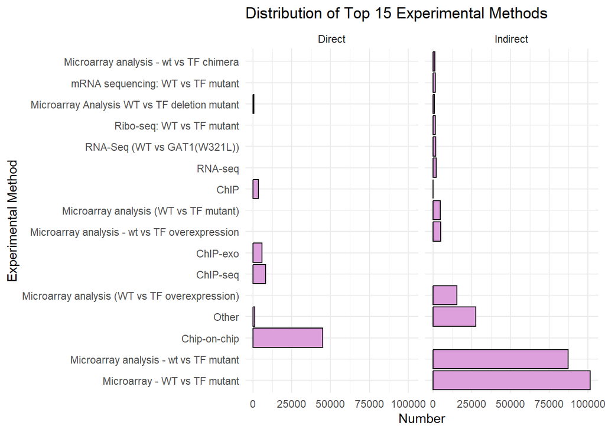

```r
yeast_network %>% filter(!is.na(Method)) %>% mutate(Method_Clean = fct_lump_n(Method, n = 15)) %>% ggplot(aes(y = fct_infreq(Method_Clean))) + geom_bar(fill = "plum", color = "black") + labs(title = "Distribution of Top 15 Experimental Methods", x = "Number", y = "Experimental Method") + theme_minimal() + facet_wrap(~ Type)
```

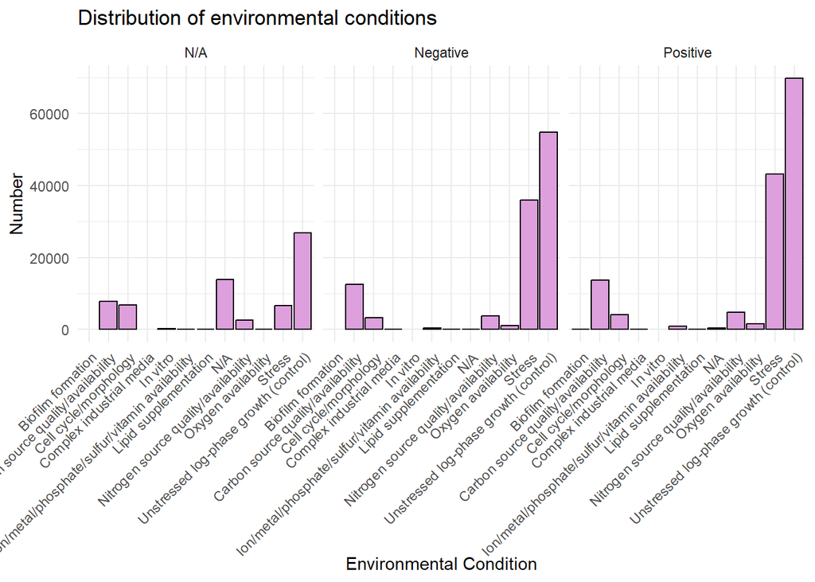

```r
ggplot(yeast_network, aes(x = Environment)) + geom_bar(fill = "plum", color = "black") + labs(title = "Distribution of environmental conditions", x = "Environmental Condition", y = "Number") + theme_minimal() + theme(axis.text.x = element_text(angle = 45, hjust = 1)) + facet_wrap(~ Regulation)
```

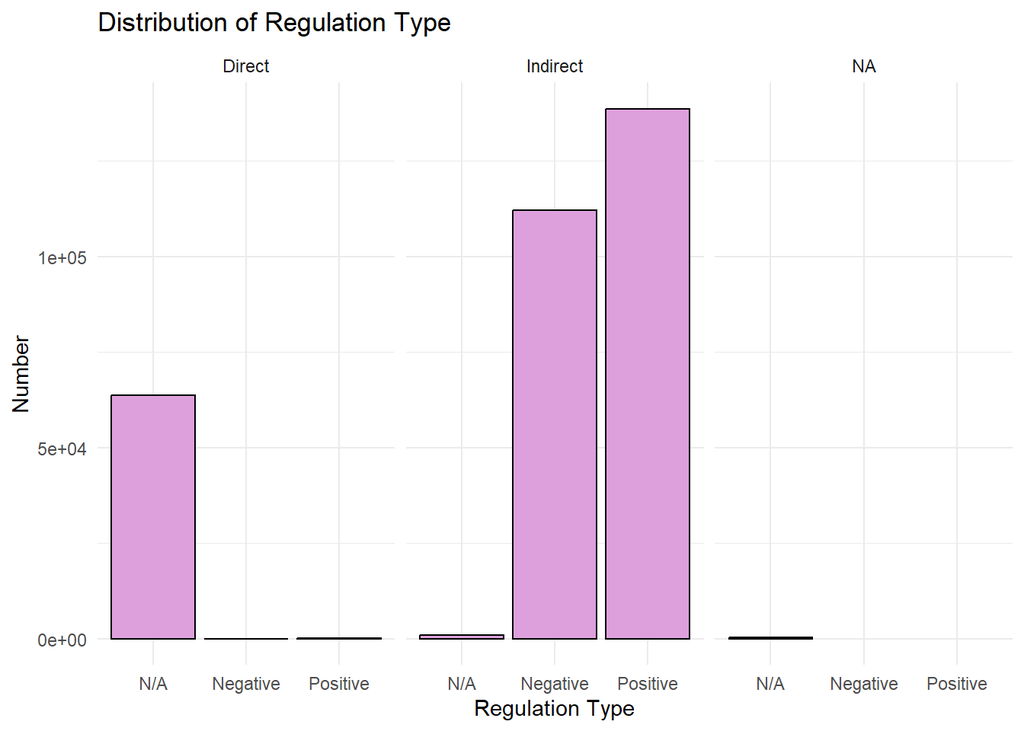

```r
ggplot(yeast_network, aes(x = Regulation)) + geom_bar(fill = "plum", color = "black") + labs(title = "Distribution of Regulation Type", x = "Regulation Type", y = "Number") + theme_minimal() + facet_wrap(~ Type)
```

As shown in the plots above, there are some imbalances

**Regulation Type split by Interaction Type:** Direct Interactions are mostly N/A: For direct interactions (often derived from high-throughput ChIP-seq or ChIP-on-chip data), the mode of regulation is predominantly unknown (N/A). Binding assays prove that a protein sits on a piece of DNA, but they cannot inherently deduce whether that binding event activates or represses transcription.

Indirect Interactions specify Direction: For indirect interactions, the direction (Positive or Negative) is almost always known. This is because these edges are derived from expression-based assays (RNA-Seq, Microarrays, Northern Blots) where an increase or decrease in target mRNA levels is directly measurable.

# Task 2

# 1 What Problem Does This Chapter Solve?

Real biological data is almost never perfectly unimodal. A single normal or Poisson distribution rarely fits — because samples come from **heterogeneous populations**: cells in different states, genes that are on or off, binding sites versus background noise.

The solution: model the data as a **mixture** of simpler distributions.

> *“Simple models such as the normal or Poisson distributions can serve as building blocks for more realistic models using the mixing framework.”* — Holmes & Huber, Ch. 4

# 2 Mathematical Background

## 2.1 Probability Densities

A **density function** $f(x)$ describes the shape of a continuous distribution. The most important one in this chapter is the **normal density**:

$$\phi(x) = \frac{1}{\sigma\sqrt{2\pi}}
\exp\!\left(-\frac{1}{2}\left(\frac{x-\mu}{\sigma}\right)^2\right)$$

In R: `dnorm(x, mean = µ, sd = σ)`

## 2.2 Finite Mixture Densities

A **mixture** is a weighted sum of component densities. For two normals with mixing weight $\lambda \in [0,1]$:

$$f(x) = \lambda\,\phi_1(x) +
(1-\lambda)\,\phi_2(x)$$

where $\phi_k$ is a normal with mean $\mu_k$ and standard deviation $\sigma_k$. The full parameter vector is $\theta = (\mu_1, \mu_2, \sigma_1, \sigma_2, \lambda)$.

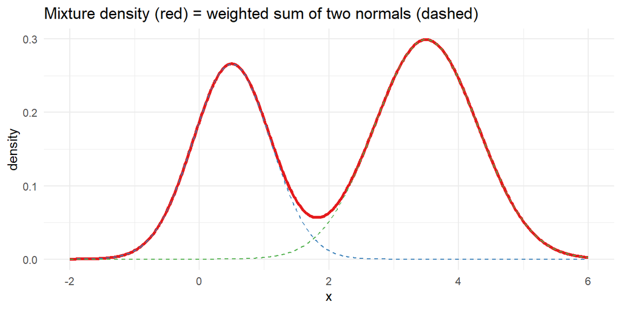

```r
x     <- seq(-2, 6, length.out = 500)
mus   <- c(0.5, 3.5); sds <- c(0.6, 0.8); lambda <- 0.4

f_mix <- lambda * dnorm(x, mus[1], sds[1]) +
         (1 - lambda) * dnorm(x, mus[2], sds[2])

ggplot(tibble(x, f_mix), aes(x, f_mix)) +
  geom_line(colour = "#E41A1C", linewidth = 1.2) +
  geom_line(aes(y = lambda * dnorm(x, mus[1], sds[1])),
            colour = "#377EB8", linetype = "dashed") +
  geom_line(aes(y = (1-lambda) * dnorm(x, mus[2], sds[2])),
            colour = "#4DAF4A", linetype = "dashed") +
  labs(title = "Mixture density (red) = weighted sum of two normals (dashed)",
       y = "density") +
  theme_minimal()
```

## 2.3 Latent Variables

The key idea: each observation $x_i$ was generated by **one** of the components, but we don’t know which. We introduce a **hidden (latent) variable** $U_i \in \{1, 2\}$ that encodes the true component membership.

The **joint probability** of observing $x$ with hidden label $u$ is:

$$p(x, u \mid \theta) = p(x \mid u,
\theta) \cdot p(u \mid \theta)$$

If we knew all $u_i$, parameter estimation would be trivial — just fit each group separately. The challenge: we don’t know them.

## 2.4 Maximum Likelihood

We want to find $\theta$ that makes the observed data most probable. The **marginal likelihood** integrates (sums) over all possible hidden states:

$$L_{\text{marg}}(\theta;\, x) =
\prod_{i=1}^n \sum_{u=1}^{2} p(x_i, u \mid \theta)$$

Directly maximising this is **intractable** — the parameters and the hidden labels are tangled together in a circular dependency. This is exactly the problem the EM algorithm solves.

## 2.5 Posterior Membership Weights (Bayes)

Given current parameters, we can ask: *how likely is it that observation $x_i$ came from component 1?* By Bayes’ theorem, this **posterior probability** is:

$$w(x_i, 1) =
\frac{\lambda\,\phi_1(x_i)}{\lambda\,\phi_1(x_i) +
(1-\lambda)\,\phi_2(x_i)}$$

These weights are the core of the E-step. They are **soft** assignments: each observation can partially belong to both components.

## 2.6 Weighted Mean and Variance

Given membership weights $w_i$ for component 1, the weighted MLE estimates are:

$$\hat{\mu}_1 = \frac{\sum_i w_i\,
x_i}{\sum_i w_i}, \qquad
\hat{\sigma}_1^2 = \frac{\sum_i w_i\,(x_i - \hat{\mu}_1)^2}{\sum_i
w_i}$$

These are used in the M-step.

# 3 The EM Algorithm — Explained

## The basic problem

Imagine you have a histogram with two humps. You suspect the data comes from two different groups mixed together — say, two cell populations — but you have no label telling you which data point belongs to which group. You want to figure out the mean and spread of each group, and how many data points came from each.

The problem is circular: to estimate the group parameters, you need to know which points belong to which group. But to know that, you need the parameters. EM gets out of this loop by making an educated guess, then improving it step by step.

## How it works

**Start:** Pick some initial parameter values — even random ones work.

**E-step (Expectation):** Given the current parameter guesses, calculate for each data point how likely it is to come from each group. This gives a probability between 0 and 1, not a hard yes/no. A point that sits right between the two humps might get 0.5/0.5; a point far out on one side might get 0.95/0.05. These probabilities are called membership weights.

**M-step (Maximisation):** Now use those weights to re-estimate the parameters. Instead of computing a plain mean, you compute a *weighted* mean — points with high weight for group 1 pull the mean of group 1 more strongly. Same for the standard deviation and the mixing fraction $\lambda$.

**Repeat:** Plug the new parameters back into the E-step, get new weights, update the parameters again — and so on, until nothing changes much anymore.

## Why it converges

Every E→M cycle is guaranteed to increase the log-likelihood (or keep it the same). So the algorithm always moves toward a better fit, never away from it. In practice you stop once the improvement per iteration drops below some small threshold. One caveat: EM finds a *local* maximum, not necessarily the global one. Running it from several different starting points and checking that you always end up at the same solution is a simple safeguard.

## What makes this useful

The key insight is that you never have to commit to a hard group assignment. A data point that sits ambiguously between two components contributes to both, weighted by how plausible each is. This “soft” membership is more honest than pretending you know something you don’t — and it leads to better estimates, especially when the two components overlap.

# 4 EM Step by Step in R

Below is the complete EM implementation from the book (Exercise 4.1), annotated to make every step visible.

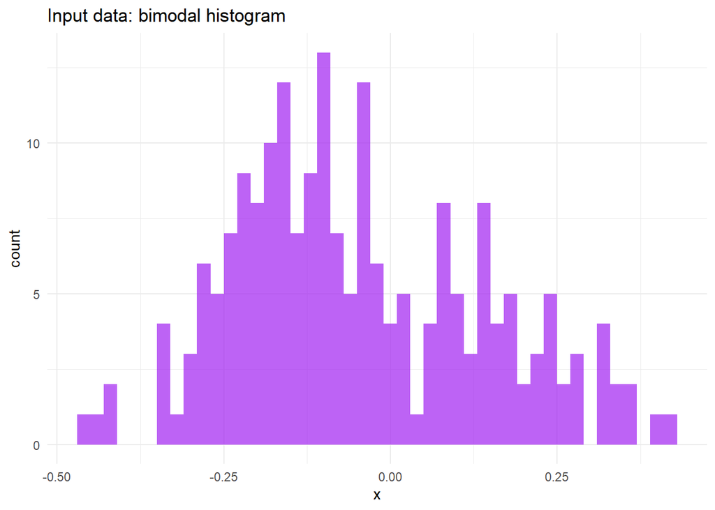

```r
set.seed(42)

# ── Simulate data from a known mixture ───────────────────────────────────────
n_A  <- 120;  mu_A <- -0.17;  sd_A <- 0.10
n_B  <-  80;  mu_B <-  0.15;  sd_B <- 0.15
mx   <- c(rnorm(n_A, mu_A, sd_A), rnorm(n_B, mu_B, sd_B))

ggplot(tibble(mx), aes(x = mx)) +
  geom_histogram(binwidth = 0.02, fill = "purple", alpha = 0.7) +
  labs(title = "Input data: bimodal histogram", x = "x", y = "count") +
  theme_minimal()
```

```r
# ── Initialise ────────────────────────────────────────────────────────────────
set.seed(7)
wA        <- runif(length(mx));  wB <- 1 - wA
iter      <- 0;   loglik <- -Inf;   delta <- +Inf
tolerance <- 1e-12;   miniter <- 50;   maxiter <- 1000

loglik_trace <- numeric(0)   # track convergence

# ── EM loop ───────────────────────────────────────────────────────────────────
while ((delta > tolerance && iter <= maxiter) || iter < miniter) {

  # ── M-STEP: update parameters given current weights ───────────────────────
  lambda <- mean(wA)                              # mixing fraction
  muA    <- weighted.mean(mx, wA)                 # mean of component A
  muB    <- weighted.mean(mx, wB)                 # mean of component B
  sdA    <- sqrt(weighted.mean((mx - muA)^2, wA)) # sd of component A
  sdB    <- sqrt(weighted.mean((mx - muB)^2, wB)) # sd of component B

  # ── E-STEP: update weights given current parameters ───────────────────────
  pA   <-      lambda  * dnorm(mx, muA, sdA)   # weighted density, component A
  pB   <- (1 - lambda) * dnorm(mx, muB, sdB)   # weighted density, component B
  ptot <- pA + pB                               # normalising constant
  wA   <- pA / ptot                             # posterior P(component A | x_i)
  wB   <- pB / ptot                             # posterior P(component B | x_i)

  # ── Convergence check ─────────────────────────────────────────────────────
  loglikOld <- loglik
  loglik    <- sum(log(ptot))
  delta     <- abs(loglikOld - loglik)
  iter      <- iter + 1
  loglik_trace <- c(loglik_trace, loglik)
}

cat("Converged after", iter, "iterations\n\n")
```

```
## Converged after 265 iterations
```

```r
cat("Estimated parameters:\n")
```

```
## Estimated parameters:
```

```r
cat(sprintf("  lambda = %.3f  (true: %.3f)\n", lambda, n_A / (n_A + n_B)))
```

```
##   lambda = 0.313  (true: 0.600)
```

```r
cat(sprintf("  muA    = %.3f  (true: %.3f)\n", muA, mu_A))
```

```
##   muA    = 0.173  (true: -0.170)
```

```r
cat(sprintf("  muB    = %.3f  (true: %.3f)\n", muB, mu_B))
```

```
##   muB    = -0.147  (true: 0.150)
```

```r
cat(sprintf("  sdA    = %.3f  (true: %.3f)\n", sdA, sd_A))
```

```
##   sdA    = 0.112  (true: 0.100)
```

```r
cat(sprintf("  sdB    = %.3f  (true: %.3f)\n", sdB, sd_B))
```

```
##   sdB    = 0.113  (true: 0.150)
```

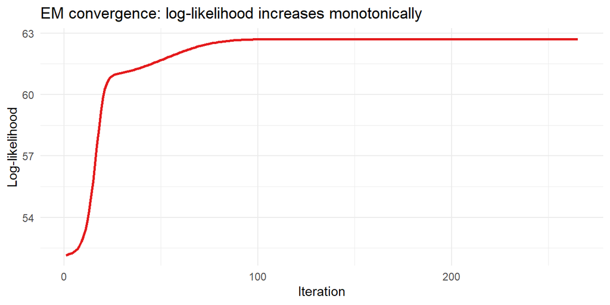

```r
# ── Log-likelihood over iterations ────────────────────────────────────────────
ggplot(tibble(iter = seq_along(loglik_trace), ll = loglik_trace),
       aes(iter, ll)) +
  geom_line(colour = "#E41A1C", linewidth = 1) +
  labs(title = "EM convergence: log-likelihood increases monotonically",
       x = "Iteration", y = "Log-likelihood") +
  theme_minimal()
```

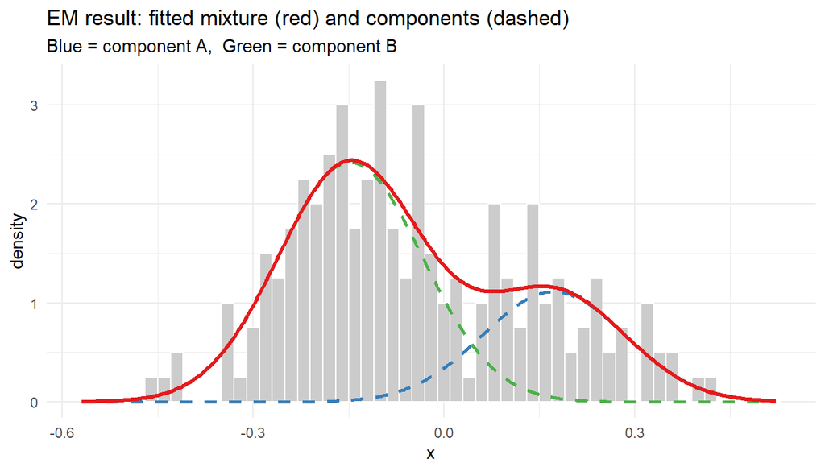

```r
# ── Show fitted components on top of data ─────────────────────────────────────
xseq   <- seq(min(mx) - 0.1, max(mx) + 0.1, length.out = 400)
fit_df <- tibble(
  x     = xseq,
  total = lambda * dnorm(xseq, muA, sdA) + (1-lambda) * dnorm(xseq, muB, sdB),
  compA =    lambda  * dnorm(xseq, muA, sdA),
  compB = (1-lambda) * dnorm(xseq, muB, sdB)
)

ggplot() +
  geom_histogram(data = tibble(mx), aes(x = mx, y = after_stat(density)),
                 binwidth = 0.02, fill = "grey80", colour = "white") +
  geom_line(data = fit_df, aes(x, compA), colour = "#377EB8",
            linetype = "dashed", linewidth = 1) +
  geom_line(data = fit_df, aes(x, compB), colour = "#4DAF4A",
            linetype = "dashed", linewidth = 1) +
  geom_line(data = fit_df, aes(x, total), colour = "#E41A1C", linewidth = 1.2) +
  labs(title = "EM result: fitted mixture (red) and components (dashed)",
       subtitle = "Blue = component A,  Green = component B",
       x = "x", y = "density") +
  theme_minimal()
```

# 5 Other Mixture Types in the Chapter

## 5.1 Zero-inflation (ChIP-Seq)

Many count datasets have an excess of zeros — more than any single distribution would predict. The **zero-inflated model** is an explicit two-component mixture:

$$f_{\text{zi}}(x) = \lambda\,\delta(x) +
(1-\lambda)\,f_{\text{count}}(x)$$

- Component 1: a point mass at 0 (e.g. genomic regions with no binding)
- Component 2: a count distribution (Poisson or negative binomial) for regions with real signal

## 5.2 The Laplace Distribution as an Infinite Mixture

The **symmetric Laplace** arises from a two-level model:

$$W \sim \text{Exp}(1), \qquad X \mid W
\sim N(\mu,\, W)$$

Each data point has its own variance drawn from an exponential distribution. This creates **heavier tails** than a normal — useful for modelling microarray log-ratios and promoter lengths.

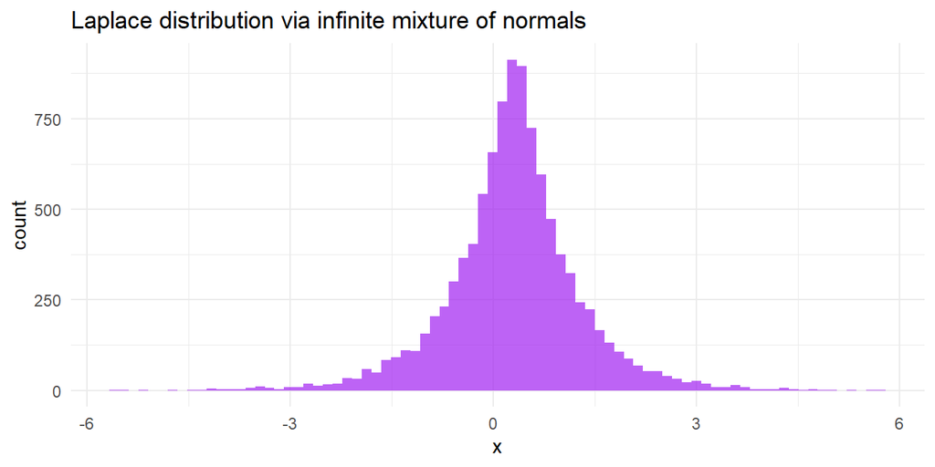

```r
set.seed(1)
w  <- rexp(1e4, rate = 1)
lp <- rnorm(length(w), mean = 0.3, sd = sqrt(w))

ggplot(tibble(lp), aes(x = lp)) +
  geom_histogram(bins = 80, fill = "purple", alpha = 0.7) +
  labs(title = "Laplace distribution via infinite mixture of normals",
       x = "x", y = "count") +
  theme_minimal()
```

## 5.3 Gamma-Poisson (Negative Binomial)

For overdispersed count data (e.g. RNA-Seq):

$$\lambda_i \sim \text{Gamma}(a, b),
\qquad K_i \mid \lambda_i \sim \text{Poisson}(\lambda_i)$$

The marginal distribution of $K$ is the **gamma-Poisson** (= negative binomial). Its variance $\mu + \alpha\mu^2$ exceeds the Poisson variance $\mu$ by an overdispersion term $\alpha\mu^2$ — crucial for modelling between-replicate variability in sequencing data.

## 5.4 Variance-Stabilising Transformations

Hierarchical models create **heteroscedasticity**: variance depends on the mean. This violates many downstream methods. The **delta method** shows: to make variance constant, apply transformation $g$ where $g'(x) = 1/\sqrt{v(x)}$ and $v$ is the mean-variance relationship.

| Distribution | Mean-variance | Transformation |
| --- | --- | --- |
| Poisson | $v = \mu$ | $g(x) = \sqrt{x}$ |
| Constant CV | $v = \alpha\mu^2$ | $g(x) = \log(x)$ |
| Gamma-Poisson | $v = \mu + \alpha\mu^2$ | $g_\alpha(x) = \text{arcosh}(2\alpha x + 1)/(2\sqrt{\alpha})$ |

The arcsinh/arcosh family interpolates between $\sqrt{x}$ (small counts) and $\log(x)$ (large counts) — which is exactly why `log2(count + 1)` and `asinh` are so widely used in genomics.

## 5.5 Nonparametric Bootstrap

The empirical distribution of $n$ observations is itself a mixture of $n$ point masses:
$$\hat{f}_n(x) = \frac{1}{n}\sum_{i=1}^n
\delta_{x_i}(x)$$

**Bootstrapping** draws new samples from this mixture (sampling with replacement) to approximate the sampling distribution of any statistic — without assuming a parametric form. This makes it universally applicable.

# 6 Summary

| Concept | Role in Chapter 4 |
| --- | --- |
| Normal density $\phi(x)$ | Building block for finite mixtures |
| Mixture density | Weighted sum of component densities |
| Latent variable $U$ | Hidden group label; never observed |
| Marginal likelihood | What EM maximises indirectly |
| Posterior weight $w(x_i, k)$ | Soft assignment; core of E-step |
| Weighted MLE | Core of M-step |
| Gamma distribution | Upper level of hierarchical count model |
| Gamma-Poisson | Mixture model for overdispersed RNA-Seq counts |
| Laplace distribution | Infinite normal mixture; heavy tails |
| Delta method | Derives variance-stabilising transformations |
| Bootstrap | Nonparametric sampling distribution via mixture of point masses |

**Relationship to Chapter 5 (Clustering):**  
EM assigns each point a **probabilistic** membership — a soft cluster. k-Means and PAM make **hard** assignments. Both are trying to solve the same underlying problem; EM is the more principled probabilistic version.